# Logistic Regression with Imbalanced Data

Author

Anna Ceslavska

```r
admits <- admits %>%
  mutate(enrollment = enrolling_stage) %>%
  select(-year, -period, -prospect_id, -enrolling_stage)  # drop unused/reference vars
```

## Introduction

In this section, I aim to predict student enrollment using logistic regression. One of the main challenges is the class imbalance in the dataset: most students do not enroll, making it difficult for standard classifiers to learn meaningful decision boundaries.

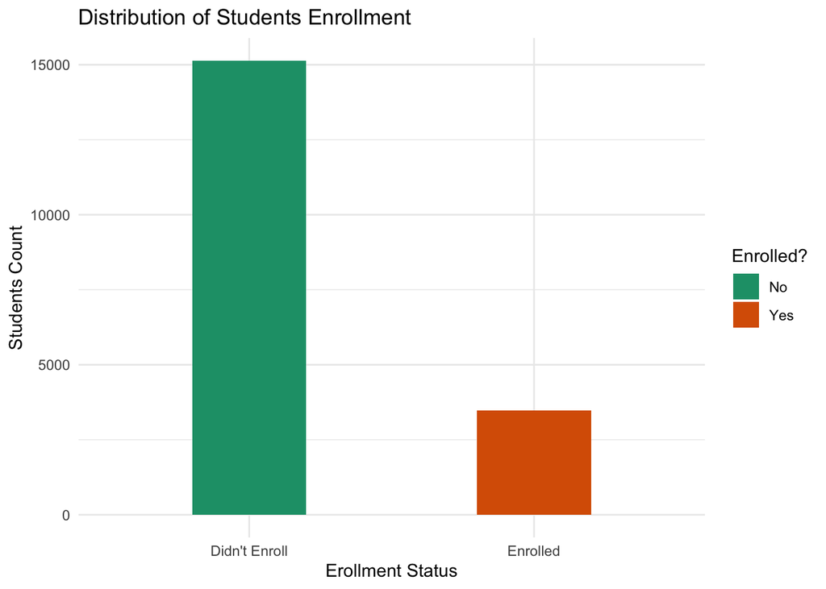

```r
ggplot(admits, aes(x = factor(enrollment, labels = c("Didn't Enroll", "Enrolled")),
                        fill = factor(enrollment, labels = c("No", "Yes")))) +
 geom_bar(width = 0.4) +
  scale_fill_brewer(palette = "Dark2") +
  labs(x = "Erollment Status",
       y = "Students Count",
       title = "Distribution of Students Enrollment",
       fill = "Enrolled?") +
  theme_minimal()
```

To address this, I apply and compare three common techniques for handling imbalanced data:

- **Undersampling** the majority class
- **SMOTE** (Synthetic Minority Oversampling Technique)
- **Weighted logistic regression**

To prepare the dataset for classification modeling, I first converted the target variable, `enrollment`, into a factor with levels `0` (not enrolled) and `1` (enrolled). This ensures compatibility with classification algorithms in R, which require the response variable to be categorical

```r
# Convert target to factor
admits$enrollment <- factor(admits$enrollment, levels = c(0, 1))
```

Next, I split the dataset into a training and testing set using a 70/30 ratio. To preserve the class distribution of the target variable (`enrollment`) and avoid introducing bias due to class imbalance, I used stratified sampling. This step ensures both subsets maintain a proportional representation of each class, which is crucial for evaluating model performance accurately.

```r
# Train/test split
set.seed(123)
split <- initial_split(admits, prop = 0.7, strata = enrollment)
train <- training(split)
test <- testing(split)
```

## Undersampling

I applied **random undersampling** using `downSample()` to reduce the size of the majority class (`0 - not enrolled`) to match the minority class (`1 - enrolled`). This technique helps the model learn more balanced decision boundaries.

```r
# Undersample majority class
train_under <- downSample(x = train[, -which(names(train) == "enrollment")],
                          y = train$enrollment, yname = "enrollment")
```

#### Training set before undersampling

```r
table(train$enrollment)
```

```
    0     1
10595  2429
```

#### Training set after undersampling

```r
table(train_under$enrollment)
```

```
   0    1
2429 2429
```

#### Fitting logistic model and making predictions

Using the undersampled training set, I fit a logistic regression model to predict the likelihood of a student enrolling.

```r
# Fit logistic model
model_under <- glm(enrollment ~ ., data = train_under, family = binomial)

# Predict
pred_under <- predict(model_under, newdata = test, type = "response")
pred_class_under <- ifelse(pred_under > 0.5, 1, 0)
```

After fitting the model, I predicted enrollment outcomes on the original (unbalanced) test set and evaluated performance using a confusion matrix.

```r
# Evaluate
conf_matrix_under <- confusionMatrix(factor(pred_class_under, levels = c(0,1)), test$enrollment)
conf_matrix_under
```

```
Confusion Matrix and Statistics

          Reference
Prediction    0    1
         0 3772  226
         1  766  815

               Accuracy : 0.8222
                 95% CI : (0.8119, 0.8321)
    No Information Rate : 0.8134
    P-Value [Acc > NIR] : 0.04714

                  Kappa : 0.5118

 Mcnemar's Test P-Value : < 2e-16

            Sensitivity : 0.8312
            Specificity : 0.7829
         Pos Pred Value : 0.9435
         Neg Pred Value : 0.5155
             Prevalence : 0.8134
         Detection Rate : 0.6761
   Detection Prevalence : 0.7166
      Balanced Accuracy : 0.8071

       'Positive' Class : 0
```

The logistic regression model trained on the undersampled data achieved an accuracy of 82.2%, slightly above the baseline No Information Rate (81.3%). The balanced accuracy, accounting for both classes, was 80.7%, indicating reasonably fair performance across the imbalanced outcome.

- Sensitivity (Recall for class 0 – not enrolled): 83.1%
- Specificity (Recall for class 1 – enrolled): 78.3%
- Precision (for class 0): 94.4%
- Kappa: 0.51, suggesting moderate agreement beyond chance

While the model performs well at identifying non-enrolled students, the negative predictive value (51.6%) indicates room for improvement in detecting enrolled students.

## SMOTE

To address the class imbalance more robustly, I applied SMOTE (Synthetic Minority Oversampling Technique) using the `themis` package. SMOTE creates synthetic examples of the minority class (enrolled students), helping the model learn from more representative and diverse samples without discarding majority-class data.

Before applying SMOTE, I removed a small number of missing values in the `location` variable:

```r
train <- train %>% drop_na(location)

smote_rec <- recipe(enrollment ~ ., data = train) %>%
  step_smote(enrollment) %>%
  step_normalize(all_numeric_predictors())
```

I created a modeling recipe that applies SMOTE and normalizes numeric predictors, followed by a logistic regression specification using `tidymodels`:

```r
# Logistic regression spec
log_spec <- logistic_reg() %>%
  set_engine("glm") %>%
  set_mode("classification")

# Build workflow
log_wf <- workflow() %>%
  add_recipe(smote_rec) %>%
  add_model(log_spec)

# Fit model
log_fit <- fit(log_wf, data = train)
```

The logistic regression model was trained on the SMOTE-augmented dataset and evaluated on the untouched test set.

```r
pred_smote <- predict(log_fit, test, type = "prob") %>%
  bind_cols(predict(log_fit, test)) %>%
  bind_cols(test %>% select(enrollment))

# 8. Evaluate performance
conf_matrix_smote <- conf_mat(pred_smote, truth = enrollment, estimate = .pred_class)
conf_matrix_smote
```

```
          Truth
Prediction    0    1
         0 3809  235
         1  729  806
```

```r
metrics_smote <- metric_set(yardstick::accuracy, yardstick::sensitivity, yardstick::specificity, yardstick::precision, yardstick::recall, yardstick::f_meas)

metrics_table <- metrics_smote(pred_smote, truth = enrollment, estimate = .pred_class)
metrics_table
```

```
# A tibble: 6 × 3
  .metric     .estimator .estimate
  <chr>       <chr>          <dbl>
1 accuracy    binary         0.827
2 sensitivity binary         0.839
3 specificity binary         0.774
4 precision   binary         0.942
5 recall      binary         0.839
6 f_meas      binary         0.888
```

The logistic regression model trained on SMOTE-augmented data achieved an accuracy of 82.7%, slightly outperforming both the baseline No Information Rate (81.3%) and the undersampled model. The balanced accuracy was 80.7%, suggesting fair performance across both enrolled and non-enrolled student groups.

- Sensitivity (Recall for class 0 – not enrolled): 83.9%
- Specificity (Recall for class 1 – enrolled): 77.4%
- Precision (for class 0): 94.2%
- F1 Score: 88.8%

These results indicate that the model is highly effective at identifying non-enrolled students, with strong precision and recall. While the specificity is slightly lower than the sensitivity, the high F1 score suggests that the model strikes a solid balance between false positives and false negatives.

## Weighted Logistic Regression

To handle the imbalance between enrolled and non-enrolled students without losing data or generating synthetic samples, I applied class weighting during logistic regression training. This method penalizes misclassification of the minority class more heavily, encouraging the model to pay closer attention to enrolled students.

```r
class_weights <- ifelse(train$enrollment == 1,
                        1 / sum(train$enrollment == 1),
                        1 / sum(train$enrollment == 0))

model_weighted <- glm(enrollment ~ ., data = train, family = binomial, weights = class_weights)
```

```r
# Predict
pred_weighted <- predict(model_weighted, newdata = test, type = "response")
pred_class_weighted <- ifelse(pred_weighted > 0.5, 1, 0)

# Evaluate
conf_matrix_weighted <- confusionMatrix(factor(pred_class_weighted, levels = c(0,1)), test$enrollment)
conf_matrix_weighted
```

```
Confusion Matrix and Statistics

          Reference
Prediction    0    1
         0 3799  229
         1  739  812

               Accuracy : 0.8265
                 95% CI : (0.8163, 0.8363)
    No Information Rate : 0.8134
    P-Value [Acc > NIR] : 0.006022

                  Kappa : 0.5192

 Mcnemar's Test P-Value : < 2.2e-16

            Sensitivity : 0.8372
            Specificity : 0.7800
         Pos Pred Value : 0.9431
         Neg Pred Value : 0.5235
             Prevalence : 0.8134
         Detection Rate : 0.6809
   Detection Prevalence : 0.7220
      Balanced Accuracy : 0.8086

       'Positive' Class : 0
```

The weighted logistic regression model yielded the following results on the test set:

- Accuracy (Recall for class 0 – not enrolled): 82.7%
- Sensitivity (Recall for class 0 – not enrolled): 83.7%
- Specificity (Recall for class 1 – enrolled): 78%
- Precision (for class 0): 94.3%

This model maintains high accuracy and precision, while offering a strong trade-off between recall and specificity, similar to SMOTE.